# Assignment 7 - Web scraping

Mie Arnau Martinez

10/31/2020

```r
# Loading relevant packages
library(pacman)
p_load(xml2)
p_load(rvest)
p_load(tidyverse) # Include tidyr, dplyr and stringr
p_load(janitor)
```

Webcraping of the worldometers website. Among others, this website holds information about population by country.

```r
# Saving the URL to an object
url <- "https://www.worldometers.info/world-population/population-by-country/"
# scraping the website
url_html <- read_html(url)

# Saving the data from the html tag "table" that captures the table from the website
table_list <- url_html %>%
 html_nodes("table") %>%
 html_table()
# This is saved as a list

# Therefore, we unlist and bind together the separate lists as different columns of a dataframe.
table_df <- as.data.frame(do.call(cbind,unlist(table_list, recursive = FALSE)))
head(table_df)
```

```
##   # Country (or dependency) Population (2020) Yearly Change Net Change
## 1 1                   China     1,439,323,776        0.39 %  5,540,090
## 2 2                   India     1,380,004,385        0.99 % 13,586,631
## 3 3           United States       331,002,651        0.59 %  1,937,734
## 4 4               Indonesia       273,523,615        1.07 %  2,898,047
## 5 5                Pakistan       220,892,340        2.00 %  4,327,022
## 6 6                  Brazil       212,559,417        0.72 %  1,509,890
##   Density (P/Km²) Land Area (Km²) Migrants (net) Fert. Rate Med. Age
## 1             153       9,388,211       -348,399        1.7       38
## 2             464       2,973,190       -532,687        2.2       28
## 3              36       9,147,420        954,806        1.8       38
## 4             151       1,811,570        -98,955        2.3       30
## 5             287         770,880       -233,379        3.6       23
## 6              25       8,358,140         21,200        1.7       33
##   Urban Pop % World Share
## 1        61 %     18.47 %
## 2        35 %     17.70 %
## 3        83 %      4.25 %
## 4        56 %      3.51 %
## 5        35 %      2.83 %
## 6        88 %      2.73 %
```

```r
# Some of the column names are quite long so I rename the one's that I am going to use
table_df <- table_df %>%
  rename(
    Country = "Country (or dependency)",
    Population = "Population (2020)",
    FertilityRate = "Fert. Rate",
    Density = "Density (P/Km²)"
    )
```

From this table, I want to visualize the fertility rate against the density (population / land area km²) to see if there is a relation between how dense the population is and how many children the women get on average.

```r
# Data cleaning
# After inspecting the data, I found that commas where used to delineate the numbers in the density and population column. Therefore, I start by removing these and transforming the values to numeric values
table_df$Population <- as.numeric(gsub("\\,", "", table_df$Population))
table_df$Density <- as.numeric(gsub("\\,", "", table_df$Density))
table_df$FertilityRate <- as.numeric(table_df$FertilityRate)
# Some of the values in FertilityRate are characters ("N.A."). Therefore, these cannot be made numeric and instead they are now labeled as NA.

# I then create some summaries of the data (mean population, mean density and mean fertility). To do this I first have to select the columns and filter out the NA's from FertilityRate.
table_df %>%
  select(Population, Density, FertilityRate) %>%
  filter(!is.na(FertilityRate)) %>%
  summarise(mean_pop = mean(Population),
            mean_dens = mean(Density),
            mean_fertil = mean(FertilityRate))
```

```
##   mean_pop mean_dens mean_fertil
## 1 38774455  358.6269    2.693035
```

From this, we can see that the average population per country is 38.8 million. Furthermore, the average population density is 359 people/Km² and the average female gets 2.7 children in their lifetime.

Now to the visualization: I want to plot the fertility rate against population density for the countries with a population greater than the average population. This is mainly to decrease the number of countries included in the plot so that it is more tangible. I also plot all countries at once to compare.

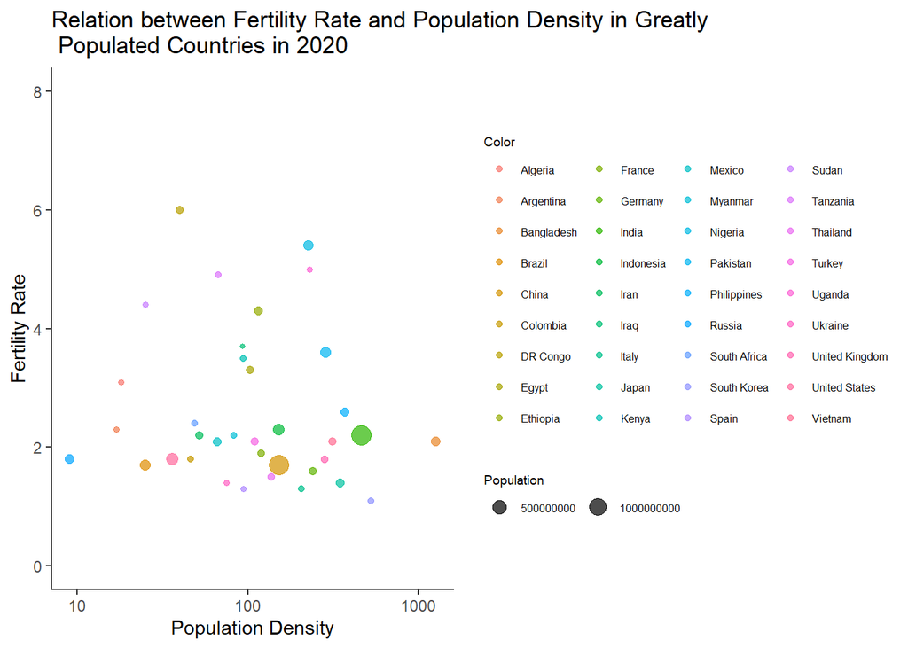

```r
# Expanding the scientific notation in the legend to whole numbers
options(scipen=999)

# Plotting the Density and FertilityRate for countries with a population above average
table_df %>%
  filter(Population > 39000000) %>%
  ggplot(aes(x = Density, y = FertilityRate, size = Population, color = Country)) +
    # Making the points more see-through by specifying the alpha < 1.
    geom_point(alpha=0.7) +
    # Changing the x axis scale to logarithmic to spread out the data points and pull outliers closer to the other data points
    scale_x_log10() +
    # Changing the scale for the size of the data points
    scale_size(range = c(1, 5)) +
    # Specifying the range of the y axis
    ylim(0, 8) +
    # Specifying the title, x label and y label.
    labs(title = "Relation between Fertility Rate and Population Density in Greatly \n Populated Countries in 2020",
         x = "Population Density",
         y = "Fertility Rate") +
    # Specifying the theme
    theme_classic() +
    # From here I just play around with the position and size of the different elements
    theme(legend.title = element_text(size = 7),
          legend.text = element_text(size = 6),
          legend.position = "right",
          legend.direction = "horizontal") +
    # The last two lines decides the position of the title of the size and color legend and how many rows there should be for the color legend
    guides(color = guide_legend(title = "Color", title.position = "top", nrow = 9),
           size = guide_legend(title = "Population", title.position = "top"))
```

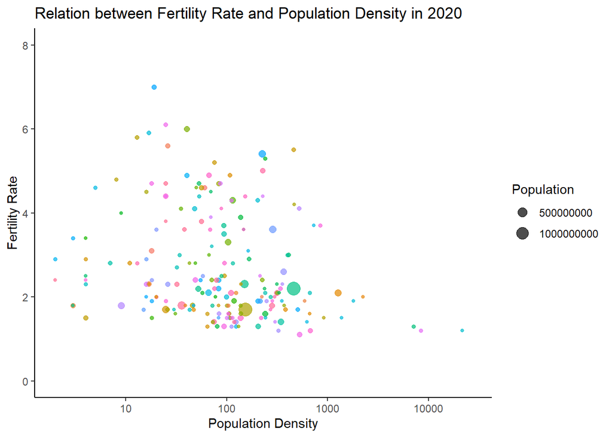

```r
# Plot of the Density and FertilityRate for all countries
table_df %>%
  ggplot(aes(x = Density, y = FertilityRate, size = Population, color = Country)) +
    geom_point(alpha = 0.7) +
    scale_size(range = c(1, 5)) +
    scale_x_log10() +
    ylim(0, 8) +
    labs(title = "Relation between Fertility Rate and Population Density in 2020",
         x = "Population Density",
         y = "Fertility Rate")+
    # Color codes for each country couldn't fit in the plot so therefore they are excluded
    guides(color = "none")+
    theme_classic()
```

Of course, more statistical test are needed to conclude anything about the relationship between fertility rate and population density. However, from the plots there doesn’t seem to be a trend in the data. This pattern is true both for the countries with the highest population as well as all countries in general.

References: I used this guide for finding out how to re-position the elements in the plots: https://ggplot2.tidyverse.org/reference/guides.html